# Motor Trend Assignment

Alan C Bonnici

Tuesday, October 21, 2014

# Assignment

You work for Motor Trend, a magazine about the automobile industry. Looking at a data set of a collection of cars, they are interested in exploring the relationship between a set of variables and miles per gallon (MPG) (outcome). They are particularly interested in the following two questions:

- “Is an automatic or manual transmission better for MPG”
- “Quantify the MPG difference between automatic and manual transmissions”

## Data

The data source for this assignment comes from the **mtcars** dataset which is bundled with R.

The resulting dataset consists of **32** rows, each row made up of **11** colunms.

The columns making up this dataset are:

1 mpg Miles/(US) gallon  
2 cyl Number of cylinders  
3 disp Displacement (cu.in.)  
4 hp Gross horsepower  
5 drat Rear axle ratio  
6 wt Weight (lb/1000)  
7 qsec 1/4 mile time  
8 vs V/S  
9 am Transmission (0 = automatic, 1 = manual)  
10 gear Number of forward gears  
11 carb Number of carburetors

The information provided here was sourced from the R documentation page. This, together with addition information can be called up by typing *?mtcars* at the R prompt. Appendix A contains a detailed description.

Below is a sample of data:

```r
tail(mtcars)
```

```
##                 mpg cyl  disp  hp drat    wt qsec vs am gear carb
## Porsche 914-2  26.0   4 120.3  91 4.43 2.140 16.7  0  1    5    2
## Lotus Europa   30.4   4  95.1 113 3.77 1.513 16.9  1  1    5    2
## Ford Pantera L 15.8   8 351.0 264 4.22 3.170 14.5  0  1    5    4
## Ferrari Dino   19.7   6 145.0 175 3.62 2.770 15.5  0  1    5    6
## Maserati Bora  15.0   8 301.0 335 3.54 3.570 14.6  0  1    5    8
## Volvo 142E     21.4   4 121.0 109 4.11 2.780 18.6  1  1    4    2
```

# Project Requirement

*am* will be converted into a factor variable.

```r
mtcars$am <- as.factor(mtcars$am)
levels(mtcars$am) <-c("Automatic", "Manual")
```

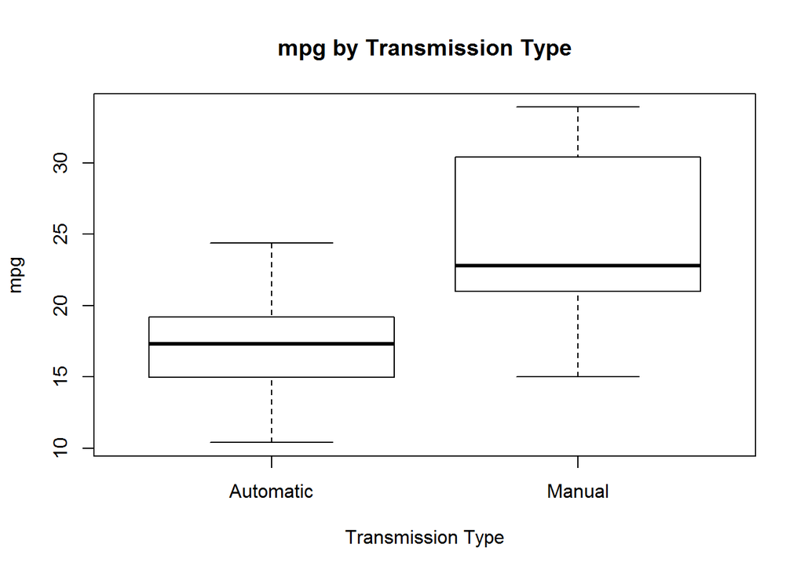

```r
boxplot(mpg~am, data = mtcars,
        xlab = "Transmission Type",
        ylab = "mpg",
        main = "mpg by Transmission Type")
```

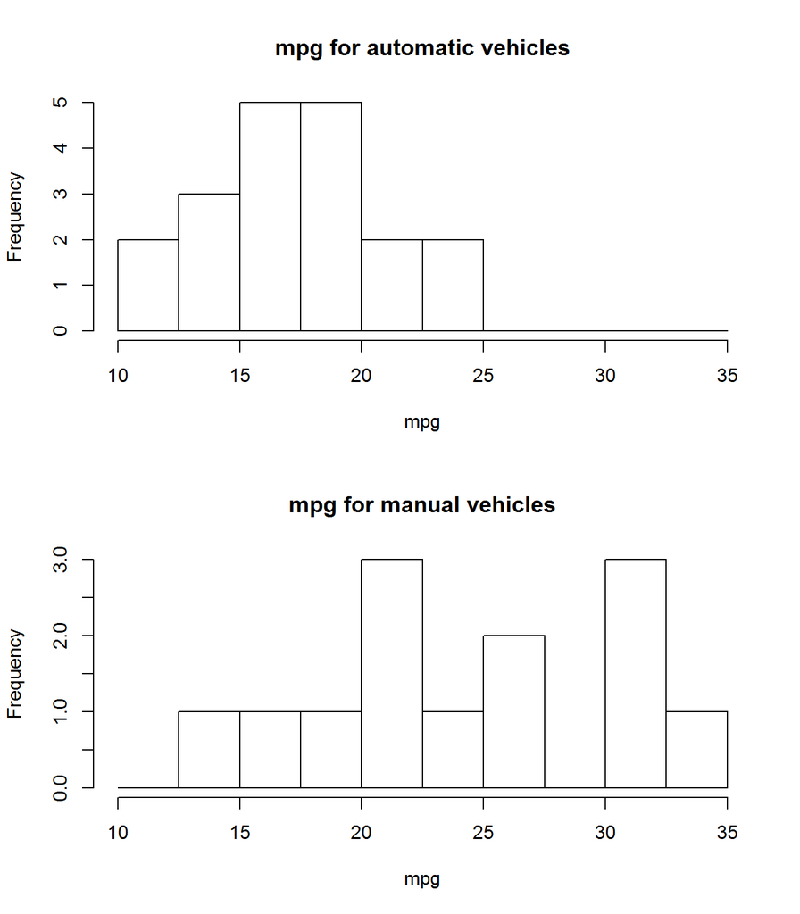

The histogram above compares the mpg of the two types of transmissions.

# Data Analaysis of mpg for automatic vs manual tranmssions

```r
cars.Auto <- mtcars[mtcars$am == "Automatic",]
cars.Man <- mtcars[mtcars$am == "Manual",]
```

The average mpg for vehciles with automatic transmssion is **17.15**. The average mpg for vehciles with manual transmssion is **24.39**.

```r
t.test(cars.Auto$mpg, cars.Man$mpg)
```

```
##
##  Welch Two Sample t-test
##
## data:  cars.Auto$mpg and cars.Man$mpg
## t = -3.7671, df = 18.332, p-value = 0.001374
## alternative hypothesis: true difference in means is not equal to 0
## 95 percent confidence interval:
##  -11.280194  -3.209684
## sample estimates:
## mean of x mean of y
##  17.14737  24.39231
```

From the information presented above, the *null hypothesis: true difference in means is equal to 0* will be rejected at the 99% confidence level.

Even though the information shown above indicates that manual is more efficient than automatic, one needs to ensure that other factors are not confounding the results. For example, if automatic cars analysed here are heavier than manual ones than weight could be “upsetting” the results. Likewise if one category of vehicle have higher, hp or cylinder values this could be a factor and not the transmission.

A correlation analysis can help show the relationship of the various properties with respect to mpg shows that an increase in cylinders, displacement, hp, weight and number of carburetors all negativly impact mpg while rear axle ratio, 1/4 mile time and number of forward gears all contribute to higher mpgs.

```r
x <- head(cor(sapply(mtcars, as.numeric)),1)
x <- x[, order(x)]
x[-11]
```

```
##         wt        cyl       disp         hp       carb       qsec
## -0.8676594 -0.8521620 -0.8475514 -0.7761684 -0.5509251  0.4186840
##       gear         am         vs       drat
##  0.4802848  0.5998324  0.6640389  0.6811719
```

## Motor Trend Car Road Tests

### Description

The data was extracted from the 1974 *Motor Trend* US magazine, and comprises fuel consumption and 10 aspects of automobile design and performance for 32 automobiles (1973–74 models).

### Usage

```
mtcars
```

### Format

A data frame with 32 observations on 11 variables.

| [, 1] | mpg | Miles/(US) gallon |
| --- | --- | --- |
| [, 2] | cyl | Number of cylinders |
| [, 3] | disp | Displacement (cu.in.) |
| [, 4] | hp | Gross horsepower |
| [, 5] | drat | Rear axle ratio |
| [, 6] | wt | Weight (lb/1000) |
| [, 7] | qsec | 1/4 mile time |
| [, 8] | vs | V/S |
| [, 9] | am | Transmission (0 = automatic, 1 = manual) |
| [,10] | gear | Number of forward gears |
| [,11] | carb | Number of carburetors |

### Source

Henderson and Velleman (1981), Building multiple regression models interactively. *Biometrics*, **37**, 391–411.

### Examples

```
require(graphics)
pairs(mtcars, main = "mtcars data")
coplot(mpg ~ disp | as.factor(cyl), data = mtcars,
       panel = panel.smooth, rows = 1)
```

[Package *datasets* version 3.1.1 Index]

A link to the online version of the page is available at (https://stat.ethz.ch/R-manual/R-devel/library/datasets/html/mtcars.html).